# hw5_qe

Kinsey Reed

3/29/2021

Included in this homework is an example occupancy modeling dataset obtained from camera trap data across 6 mid-Atlantic states: Bobcat.csv: detection / non-detection of bobcat at each camera. Each row is a camera, and each column is a replicate survey (1 day).

p covariates.csv: number of people (divided by 100) photographed. Each row is a camera, and each column is a replicate survey (1 day). This is a detection covariate.

psi covariates.csv: the single covariate represents the proportion of area within 5km recently disturbed (e.g., logging, housing development). Treat this as a site-level covariate.

1. Load data and place into an unmarkedFrameOccu object

```r
library(unmarked)
data <- read.csv('Bobcat.csv')
head(data)
```

```
##   day1 day2 day3 day4 day5 day6 day7 day8 day9 day10 day11 day12 day13 day14
## 1    0    0    0    0    0    0    0    0    0     0     0     0     0     0
## 2    0    0    0    0    0    0    0    0    0     0     0     0     0     0
## 3    0    0    0    0    0    0    0    0    0     0     0     0     0     0
## 4    0    0    0    0    0    0    0    0    0     0     0     0     0     0
## 5    0    0    0    0    0    0    0    0    0     0     0     0     0     0
## 6    0    0    0    0    0    0    0    0    0     0     0     0     0     0
##   day15 day16 day17 day18 day19 day20 day21 day22 day23 day24 day25 day26 day27
## 1     0     0     0     0     0     0     0     0    NA    NA    NA    NA    NA
## 2     0     0     0     0     0     0    NA    NA    NA    NA    NA    NA    NA
## 3    NA    NA    NA    NA    NA    NA    NA    NA    NA    NA    NA    NA    NA
## 4     0     0     0     0    NA    NA    NA    NA    NA    NA    NA    NA    NA
## 5     0     0     0     0     0     0     0    NA    NA    NA    NA    NA    NA
## 6     0     0     0     0     0     0     0    NA    NA    NA    NA    NA    NA
##   day28 day29 day30 day31 day32 day33 day34 day35 day36 day37 day38 day39 day40
```

[output cut: 27 more lines]

```r
p_covs <- read.csv('p covariates.csv')
site_covs <- read.csv('psi covariates.csv')

#In order to place into object:
#convert detection data to matrix
data_m <- as.matrix(data)
#for both covariates, make sure categorical variables are factors (none here though)
#detection covariates as a list of data.frames
class(p_covs)#already a data.frame
```

```
## [1] "data.frame"
```

```r
#put into list
det_covs <- list(
  people = p_covs
)
#site-level covariates just need to be a data.frame, which it already is
class(site_covs)
```

```
## [1] "data.frame"
```

```r
#put all into object
occu_data <- unmarkedFrameOccu(y = data,
                               siteCovs = site_covs,
                               obsCovs = det_covs)
```

2. Fit an occupancy model that assumes conditional detection probability is a function of the number of people photographed at a site, and occupancy probability is a function of disturbance within 5km.

```r
#remember order is: ~ detection covariate (+ * etc) ~ site covariate (Etc)
fit <- occu(formula = ~ people ~ Dist_5km, data = occu_data)
summary(fit)
```

```
##
## Call:
## occu(formula = ~people ~ Dist_5km, data = occu_data)
##
## Occupancy (logit-scale):
##             Estimate    SE      z  P(>|z|)
## (Intercept)    -1.05 0.101 -10.39 2.63e-25
## Dist_5km      -23.64 4.773  -4.95 7.28e-07
##
## Detection (logit-scale):
##             Estimate     SE       z P(>|z|)
## (Intercept)  -3.0133 0.0741 -40.646   0.000
## people       -0.0609 0.3779  -0.161   0.872
##
## AIC: 4462.98
## Number of sites: 1951
## optim convergence code: 0
## optim iterations: 39
## Bootstrap iterations: 0
```

3. Interpret the effect of the number of people photographed at each site on conditional detection probability of bobcat. Verity your interpretation in R.

The 'slope coefficient' (or conditional detection probability) associated with the number of people photographed at each site is the log odds ratio (-0.061) associated with a 1-unit change in the number of people at each site.

The model is on the log odds scale, so interpretation is the same as the other binomial models and is a Bernoulli random variable.

```r
#log odds occupancy and detection probability
coef(fit)
```

```
##      psi(Int) psi(Dist_5km)        p(Int)     p(people)
##   -1.04584568  -23.64383918   -3.01330391   -0.06088908
```

```r
#occupancy probability and detection probability (since on logit-scale)
plogis(coef(fit))
```

```
##      psi(Int) psi(Dist_5km)        p(Int)     p(people)
##  2.600236e-01  5.390277e-11  4.682845e-02  4.847824e-01
```

```r
rho_0 <- plogis(coef(fit)[3] + coef(fit)[4] * 0)
rho_1 <- plogis(coef(fit)[3] + coef(fit)[4] * 1)

log((rho_1 / (1 - rho_1)) / (rho_0 / (1 - rho_0))); coef(fit)[4]
```

```
##      p(Int)
## -0.06088908
```

```
##   p(people)
## -0.06088908
```

4. Re-create the Wald test for the effect of disturbance within 5km. What is the null hypothesis? Do you reject or fail to reject this null hypothesis?

The null hypothesis is that there is no effect of disturbance within 5km on the whether or not a site is occupied. Because the p-value here is well below 0.05, we can reject that null hypothesis, meaning that the probability of occupancy depends on whether there is an effect of disturbance within 5 km on bobcat site occupation.

```r
#coefficient divided by std error
summary(fit)
```

```
##
## Call:
## occu(formula = ~people ~ Dist_5km, data = occu_data)
##
## Occupancy (logit-scale):
##             Estimate    SE      z  P(>|z|)
## (Intercept)    -1.05 0.101 -10.39 2.63e-25
## Dist_5km      -23.64 4.773  -4.95 7.28e-07
##
## Detection (logit-scale):
##             Estimate     SE       z P(>|z|)
## (Intercept)  -3.0133 0.0741 -40.646   0.000
## people       -0.0609 0.3779  -0.161   0.872
##
## AIC: 4462.98
## Number of sites: 1951
## optim convergence code: 0
## optim iterations: 39
## Bootstrap iterations: 0
```

```r
w <- -23.64 / 4.773
w
```

```
## [1] -4.95286
```

```r
2 * pnorm(-1 * abs(w))
```

```
## [1] 7.313065e-07
```

```r
#same p value: 7.31e-07
```

5. Predict and plot the effect of disturbance within 5km on bobcat occupancy probability. Do this over the range of observed disturbance within 5km.

```r
#make a data frame for occupancy (psi)
new_psi <- data.frame(Dist_5km = seq(from = min(site_covs$Dist_5km),
                                                    to = max(site_covs$Dist_5km), length.out = 100))

predict <- predict(object = fit, newdata = new_psi, type = 'state')
head(predict)
```

```
##   Predicted         SE     lower     upper
## 1 0.2600236 0.01935982 0.2239054 0.2997182
## 2 0.2540944 0.01855293 0.2194710 0.2921356
## 3 0.2482550 0.01782171 0.2149896 0.2848002
## 4 0.2425062 0.01716846 0.2104579 0.2777182
## 5 0.2368486 0.01659480 0.2058736 0.2708941
## 6 0.2312826 0.01610146 0.2012363 0.2643305
```

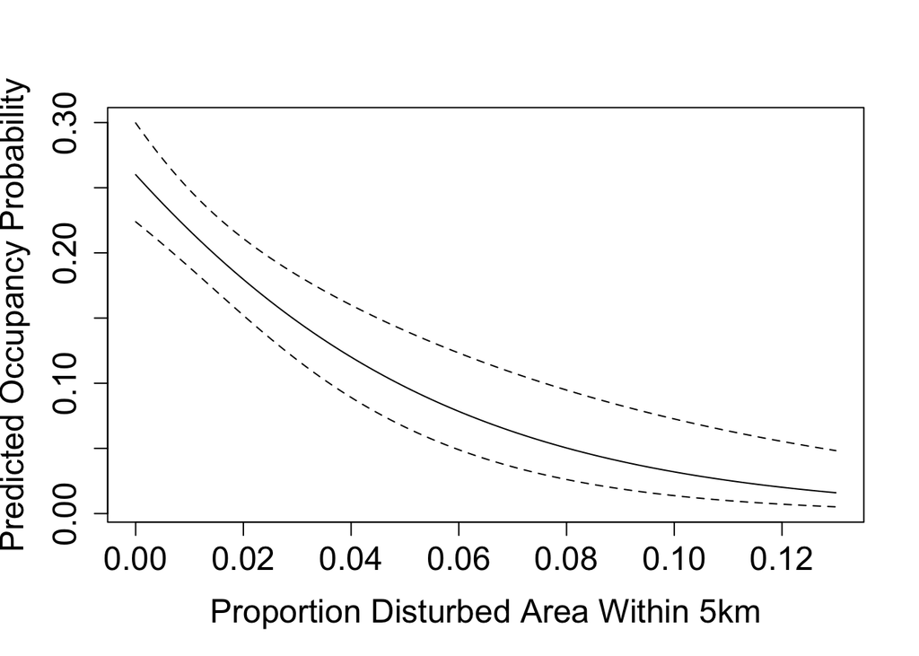

```r
#need link function here for y value?
plot(y = predict$Predicted, x = new_psi$Dist_5km, xlab = 'Proportion Disturbed Area Within 5km',
     ylab = 'Predicted Occupancy Probability', cex.axis = 1.5, cex.lab = 1.5,
     ylim = c(min(predict$lower), max(predict$upper)), type = 'l')
lines(x = new_psi$Dist_5km, y = predict$lower, lty = 2)
lines(x = new_psi$Dist_5km, y = predict$upper, lty = 2)
```